# Monte Carlo simulations

M5 ICA1

# Introduction

> Monte Carlo simulations are a statistical technique used to model probabilistic (or “stochastic”) processes and establish the odds for a variety of outcomes. The concept was first popularized right after World War II. To study nuclear fission, mathematician Stanislaw Ulam coined the term in reference to an uncle who loved playing the odds at the Monte Carlo casino (then a world symbol of gambling, like Las Vegas today).

To get started, load package `tidyverse` and set the random number generator in your setup R chunk. In the following problems you will make heavy use of functions

- `sample(x, size, replace = FALSE, prob = NULL)`,
- `replicate(n, expr, simplify = "array")`.

```r
library(tidyverse)
```

# Antoine Gombaud’s question

Which is more likely:

1. getting at least one 6 when rolling a single fair six-sided die 4 times,
2. getting at least one pair of sixes when two fair six-sided dice are thrown 24 times.

The number of simulation replications you choose is at your discretion, but if you choose a number too small the results will not be accurate.

```r
# A
die_rolls <- replicate(4, sample(1:6, 1, replace = TRUE))

die_rolls
```

```
[1] 2 5 6 3
```

```r
tab <- table(die_rolls)
prop.table(tab)
```

```
die_rolls
   2    3    5    6
0.25 0.25 0.25 0.25
```

```r
die_rolls <- replicate(24, sample(1:6, 2, replace = TRUE))

die_rolls
```

```
     [,1] [,2] [,3] [,4] [,5] [,6] [,7] [,8] [,9] [,10] [,11] [,12] [,13] [,14]
[1,]    3    1    3    5    3    6    6    2    1     4     6     6     5     6
[2,]    2    1    1    5    1    3    6    4    5     6     1     1     3     5
     [,15] [,16] [,17] [,18] [,19] [,20] [,21] [,22] [,23] [,24]
[1,]     4     2     3     4     2     1     1     2     2     5
[2,]     4     2     6     4     2     1     4     5     3     1
```

```r
tab <- table(die_rolls)
prop.table(tab)
```

```
die_rolls
        1         2         3         4         5         6
0.2291667 0.1666667 0.1458333 0.1458333 0.1458333 0.1666667
```

# Enough?

How many Monte Carlo experiments are enough?

1. Perform Monte Carlo simulation to evaluate the probability of getting “Heads” in a fair coin toss.
2. Use `ggplot()` to plot the probability estimate on the y-axis and the iteration (number of Monte Carlo) experiments on the x-axis. As the number of iterations gets large, you should see this value stabilize at around 0.50.

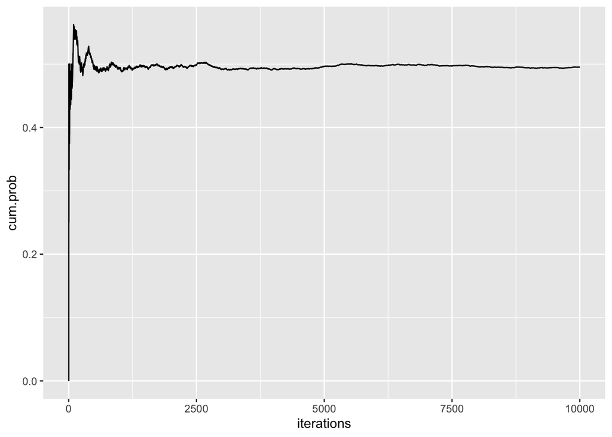

```r
#create a fuction flip() to get the result of one flip
flip <- function(n=1){

  result <- sample(c("H", "T"), size = n, replace = TRUE)

  return(result)

}
#Use the above to create a dataframe (toss.df) of 10000 replication results.
toss.df <- data.frame(toss = unlist(replicate(10000, flip(1)), use.names = FALSE))
# Use mutate to add two new columns `iterations` and `cum.prob` to the dataframe toss.df. `cum.prob` will give the cumulative probabilities of getting heads in each iteration.
toss.df <- toss.df %>%
  mutate(iterations = row_number(),
         cum.prob = cumsum(toss == "H") / iterations)
# Use ggplot and geom_line with the above dataframe to plot the iteration vs cumulative probabilities graph.

ggplot(toss.df, aes(iterations, cum.prob)) +
  geom_line()
```

# Birthday problem

You may ignore leap year and assume 365 days per year. The number of simulation replications you choose is at your discretion, but if you choose a number too small the results will not be accurate.

```r
#create a fuction bday.match(n) which will check whether there is a birthday match in a year between `n` individuals


# For (a) check probability of match for 23 people
#emp.23 <- mean(replicate(100000, bday.match(23)))
#emp.23

#(b)

# Here're the steps to create the dataframe needed for part (c)
#nmat <- matrix(c(2:100))
#event.results <- replicate(10000, apply(nmat, 1, bday.match))
#emp.results <- apply(event.results, 1, mean)
#emp.results.df <- data.frame(n = nmat, emp.prob = emp.results)
```

# References

1. http://news.mit.edu/2010/exp-monte-carlo-0517
2. https://en.wikipedia.org/wiki/Antoine_Gombaud